# Multi-Wavelength Bioassay Analysis Report

Kristof Moeller (IAEA, Monaco) and Arnold Molina Porras (Universidad de Costa Rica)

# Multi-Wavelength Analysis Overview

This report contains analyses for **2 wavelengths**: 450nm, 630nm.

Each wavelength is analyzed independently using the same plate layout but different absorbance readings. This allows you to:

- Compare dose-response curve quality across wavelengths
- Identify the optimal wavelength for your assay
- Verify sample concentrations are consistent across readings

**Sections:**

- Executive Summary (below) - Quick comparison across wavelengths
- Detailed Analysis for each wavelength (following sections)

# Wavelength 450nm Analysis

**Analysis 1 of 2**

[figure not shown]

# ELISA Analysis Report

AuthorsKristof Moeller (IAEA, Monaco) · Arnold Molina Porras (Universidad de Costa Rica)

Generated2026-05-15 · root

AssayELISA — cortisol

SoftwareBioassay Analysis App v2.0 · R version 4.3.3 (2024-02-29) · drc v3.2.0

This report analyzes ELISA data using a four-parameter logistic dose–response curve to estimate concentrations of cortisol in unknown samples.

**Method: Competitive enzyme-linked immunosorbent assay with %B/B0 normalization**

## Analysis Notes

*No additional notes provided.*

## Standard Curve Configuration

**Standard Concentrations**

Standard Concentrations

| Standards | Concentration (pg/mL) |
| --- | --- |
| 1 | 4,000.0 |
| 2 | 1,600.0 |
| 3 | 640.0 |
| 4 | 256.0 |
| 5 | 102.4 |
| 6 | 41.0 |
| 7 | 16.4 |
| 8 | 6.6 |

## Methods

**Curve model:** Four-parameter log-logistic (LL.4) as implemented in the drc package (v3.2.0; Ritz et al. 2015). If LL.4 fails to converge a three-parameter model (LL.3, fixed lower asymptote = 0) is attempted; if neither converges, linear interpolation is used as a fallback.

**Weighting:** Unweighted (ordinary least squares).

**Outlier detection:** Not applied; all replicates included in group statistics.

**Software:** Bioassay Analysis App v2.0 R version 4.3.3 (2024-02-29) drc v3.2.0

## Dose–Response Curve Analysis

Analyst:**root**

Analysis Date:**2026-05-15**

Wells**72 samples / 16 standards**

R curve fit

0.9995

RMSE

0.010

Cal. low

pg/mL

Cal. high

pg/mL

Overall

Pass

**Quality Control Summary**

#### Quality Control Summary

*Regression: Unweighted (LL.4)*

> **Note:** Residual variance ratio across concentration levels = 49.8 (>3), suggesting heteroscedasticity. Weighted regression (1/Y or 1/Y²) is recommended.

### Weighting Suitability Assessment

**Test:** Brown-Forsythe (Levene, median)

**Statistic:** 1.000e+06   **p-value:** 1.1137e-124

**Variance ratio** (max/min across concentration levels): 1285.7

**Recommendation:** Weighted regression (1/Y or 1/Y) is recommended to account for unequal variance.

*Note: This diagnostic is advisory only and does not change the selected model.*

**Limits of Quantification**

#### Limits of Quantification

**LLOQ (Lower Limit of Quantification):** 41 pg/mL

**ULOQ (Upper Limit of Quantification):** 1,600 pg/mL

**Dose–Response Curve Analysis**

[interactive chart not shown]

## Model Parameters

**Four-Parameter Logistic Model Coefficients**

Four-Parameter Logistic Model Coefficients

| Parameter | Estimate | Std. Error | p-value |
| --- | --- | --- | --- |
| Hill Slope | 1.30 | 0.04 | NA |
| Bottom | 0.11 | 0.01 | NA |
| Top | 1.29 | 0.01 | NA |
| IC50 | 220.18 | 5.03 | NA |

**Model Fit Statistics:**

- **R²** = 1
- **RMSE** = 0.01 %B/B0
- **Standards Used** = 16 / 8

### Standard Back-Calculation and Recovery

**Click to expand standard back-calculation and recovery**

Standard Back-Calculation and Recovery

| Nominal (pg/mL) | n | Back-Calc. (pg/mL) | SD (pg/mL) | Recovery (%) |
| --- | --- | --- | --- | --- |
| 4,000.0 | 2 | 5,381.10 | 3202.869 | 134.53 |
| 1,600.0 | 2 | 1,602.62 | 63.803 | 100.16 |
| 640.0 | 2 | 624.07 | 27.157 | 97.51 |
| 256.0 | 2 | 259.76 | 3.807 | 101.47 |
| 102.4 | 2 | 102.27 | 0.976 | 99.87 |
| 41.0 | 2 | 40.82 | 4.215 | 99.56 |
| 16.4 | 2 | 12.42 | 0.175 | 75.72 |
| 6.6 | 2 | 10.68 | 5.132 | 161.86 |

**Overall Mean Recovery: 108.8%** Overall recovery is within acceptable range (80–120%).

## Sample Concentration Results

### Detailed Sample Results Summary

† Lower bound truncated to 0 (original value was negative) for: BA, BB, BC, BD, BE, BF, BG, BH, DA, DB, DG

**Output Files Created:** - `unknown_results.csv` - Individual well results - `unknown_results_summary.csv` - Replicate group statistics with confidence intervals

**⚠️ Quality Alert:** - Replicate groups with high variability (CV > 30%): BA, BB, BC, BD, BE, BF, BG, BH - Consider checking sample preparation or dilution consistency

*95% confidence intervals calculated using t-distribution.*

*Replicate-level CIs reflect measurement variability using Student’s t-distribution (df = n-1).*

*Individual sample concentrations include CIs from inverse prediction (delta method), accounting for curve-fitting uncertainty.*

*Lower confidence bounds are constrained to zero, as negative concentrations have no biological meaning. This may result in asymmetric confidence intervals.*

## Detailed Sample Results Summary

**Detailed Sample Results Summary**

##### How to read this table

The **Range** column flags whether a sample’s mean concentration falls within the calibration curve:

Row colouring is independent of the Range flag and indicates measurement quality:

A row can carry both treatments if it is both out-of-range and imprecise.

Detailed Sample Results with Model-Based Confidence Intervals

[output not shown]

## Sample Variability Visualization

**Sample variability visualization**

## Plate Heatmap

**Plate Heatmap**

Visual representation of raw measurement values across the plate.

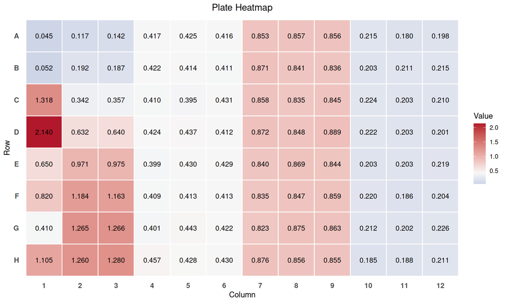

**Click to expand plate positional quality**

#### Plate Positional Quality

No significant row or column bias detected (all within 2 SD of plate mean).

Response by Row

| Row | Mean Response | SD | Flag |
| --- | --- | --- | --- |
| A | 0.39 | 0.30 | OK |
| B | 0.41 | 0.29 | OK |
| C | 0.54 | 0.35 | OK |
| D | 0.66 | 0.53 | OK |
| E | 0.59 | 0.30 | OK |
| F | 0.63 | 0.36 | OK |
| G | 0.62 | 0.39 | OK |
| H | 0.68 | 0.41 | OK |

## Dose-Response Curve with Unknown Samples

**Dose-Response Curve with Unknown Samples**

[interactive chart not shown]

## Parallelism and Relative Potency

*Not applicable: Fewer than 2 independent standard curves available for parallelism testing.*

## Interpretation & Recommendations

**Quality warnings detected:** High sample CV (max 79.8% > 15% limit). Review flagged items before use.

> **Two independent range indicators appear in this report:**
> - **Interpolated / Extrapolated** refers to whether the estimated concentration falls within the range of fitted standard concentrations on this plate. This is a statement about curve coverage.
> - **Within range / ULOQ** refers to whether the estimate falls within the validated linear (quantifiable) range of the dose-response curve, defined by EC20/EC80 for RBA or %B/B0 bounds (default 20–80%) for ELISA. This is a statement about reporting quality.

> A sample can be interpolated but outside the quantifiable range (e.g., the response falls on the flat portion of the curve near the top or bottom asymptote), or within the quantifiable range but technically extrapolated (if the user provided few standards). Both flags should be considered when interpreting results.

**Quantification status breakdown (per well):**

- Interpolated: 72

*QC profile: ELISA (R² >= 0.98, CV <= 15%, Hill slope [-3.0, -0.2], Recovery [80%, 120%])*

### Exclusion Audit

**Exclusion Audit Trail**

*No exclusions were applied during this analysis.*

**Abbreviations**

**RBA**

Radioligand Binding Assay

**ELISA**

Enzyme-Linked Immunosorbent Assay

**LL.4**

Four-parameter log-logistic dose-response function

**IC50**

Half-maximal inhibitory concentration

**EC20**

Concentration producing 20% of maximal response

**EC80**

Concentration producing 80% of maximal response

**%B/B0**

Percent bound relative to maximum specific binding (B0)

**B0**

Maximum specific binding (zero-standard well)

**NSB**

Non-specific binding

**LLOQ**

Lower Limit of Quantification

**ULOQ**

Upper Limit of Quantification

**Cal. high**

Upper limit of the calibration curve (concentration of the highest standard)

**Cal. low**

Lower limit of the calibration curve (concentration of the lowest standard)

**CV**

Coefficient of variation between replicate wells, %. Replicates with CV > 30% are flagged with a red left-border on the row.

**SD**

Standard Deviation

**SE**

Standard Error of the Mean

**CI**

Confidence Interval

**Report Generated:** 2026-05-15 **Contact:** kr.moeller@iaea.org **Feedback:** [Online Form](https://forms.office.com/e/q8eqJfp4QM)

*Automated bioassay analysis using modular system v2.0*

# Wavelength 630nm Analysis

**Analysis 2 of 2**

[figure not shown]

# ELISA Analysis Report

AuthorsKristof Moeller (IAEA, Monaco) · Arnold Molina Porras (Universidad de Costa Rica)

Generated2026-05-15 · root

AssayELISA — cortisol

SoftwareBioassay Analysis App v2.0 · R version 4.3.3 (2024-02-29) · drc v3.2.0

This report analyzes ELISA data using a four-parameter logistic dose–response curve to estimate concentrations of cortisol in unknown samples.

**Method: Competitive enzyme-linked immunosorbent assay with %B/B0 normalization**

## Analysis Notes

*No additional notes provided.*

## Standard Curve Configuration

**Standard Concentrations**

Standard Concentrations

| Standards | Concentration (pg/mL) |
| --- | --- |
| 1 | 4,000.0 |
| 2 | 1,600.0 |
| 3 | 640.0 |
| 4 | 256.0 |
| 5 | 102.4 |
| 6 | 41.0 |
| 7 | 16.4 |
| 8 | 6.6 |

## Methods

**Curve model:** Four-parameter log-logistic (LL.4) as implemented in the drc package (v3.2.0; Ritz et al. 2015). If LL.4 fails to converge a three-parameter model (LL.3, fixed lower asymptote = 0) is attempted; if neither converges, linear interpolation is used as a fallback.

**Weighting:** Unweighted (ordinary least squares).

**Outlier detection:** Not applied; all replicates included in group statistics.

**Software:** Bioassay Analysis App v2.0 R version 4.3.3 (2024-02-29) drc v3.2.0

## Dose–Response Curve Analysis

Analyst:**root**

Analysis Date:**2026-05-15**

Wells**72 samples / 16 standards**

R curve fit

0.9994

RMSE

0.010

Cal. low

pg/mL

Cal. high

pg/mL

Overall

Pass

**Quality Control Summary**

#### Quality Control Summary

*Regression: Unweighted (LL.4)*

> **Note:** Residual variance ratio across concentration levels = 20.8 (>3), suggesting heteroscedasticity. Weighted regression (1/Y or 1/Y²) is recommended.

### Weighting Suitability Assessment

**Test:** Brown-Forsythe (Levene, median)

**Statistic:** 1.000e+06   **p-value:** 1.0208e-124

**Variance ratio** (max/min across concentration levels): 19.9

**Recommendation:** Weighted regression (1/Y or 1/Y) is recommended to account for unequal variance.

*Note: This diagnostic is advisory only and does not change the selected model.*

**Limits of Quantification**

#### Limits of Quantification

**LLOQ (Lower Limit of Quantification):** 41 pg/mL

**ULOQ (Upper Limit of Quantification):** 1,600 pg/mL

**Dose–Response Curve Analysis**

[interactive chart not shown]

## Model Parameters

**Four-Parameter Logistic Model Coefficients**

Four-Parameter Logistic Model Coefficients

| Parameter | Estimate | Std. Error | p-value |
| --- | --- | --- | --- |
| Hill Slope | 1.26 | 0.04 | NA |
| Bottom | 0.09 | 0.01 | NA |
| Top | 1.19 | 0.01 | NA |
| IC50 | 223.32 | 5.98 | NA |

**Model Fit Statistics:**

- **R²** = 0.999
- **RMSE** = 0.01 %B/B0
- **Standards Used** = 16 / 8

### Standard Back-Calculation and Recovery

**Click to expand standard back-calculation and recovery**

Standard Back-Calculation and Recovery

| Nominal (pg/mL) | n | Back-Calc. (pg/mL) | SD (pg/mL) | Recovery (%) |
| --- | --- | --- | --- | --- |
| 4,000.0 | 2 | 4,567.26 | 2462.55 | 114.18 |
| 1,600.0 | 2 | 1,680.85 | 110.85 | 105.05 |
| 640.0 | 2 | 628.47 | 45.09 | 98.20 |
| 256.0 | 2 | 256.27 | 3.19 | 100.10 |
| 102.4 | 2 | 104.10 | 1.64 | 101.66 |
| 41.0 | 2 | 40.30 | 3.83 | 98.28 |
| 16.4 | 2 | 12.31 | 2.26 | 75.08 |
| 6.6 | 2 | 10.58 | 4.80 | 160.33 |

**Overall Mean Recovery: 106.6%** Overall recovery is within acceptable range (80–120%).

## Sample Concentration Results

### Detailed Sample Results Summary

† Lower bound truncated to 0 (original value was negative) for: BA, BB, BC, BD, BE, BF, BG, BH, DA, DB, DF, DG

**Output Files Created:** - `unknown_results.csv` - Individual well results - `unknown_results_summary.csv` - Replicate group statistics with confidence intervals

**⚠️ Quality Alert:** - Replicate groups with high variability (CV > 30%): BA, BB, BC, BD, BE, BF, BG, BH - Consider checking sample preparation or dilution consistency

*95% confidence intervals calculated using t-distribution.*

*Replicate-level CIs reflect measurement variability using Student’s t-distribution (df = n-1).*

*Individual sample concentrations include CIs from inverse prediction (delta method), accounting for curve-fitting uncertainty.*

*Lower confidence bounds are constrained to zero, as negative concentrations have no biological meaning. This may result in asymmetric confidence intervals.*

## Detailed Sample Results Summary

**Detailed Sample Results Summary**

##### How to read this table

The **Range** column flags whether a sample’s mean concentration falls within the calibration curve:

Row colouring is independent of the Range flag and indicates measurement quality:

A row can carry both treatments if it is both out-of-range and imprecise.

Detailed Sample Results with Model-Based Confidence Intervals

[output not shown]

## Sample Variability Visualization

**Sample variability visualization**

## Plate Heatmap

**Plate Heatmap**

Visual representation of raw measurement values across the plate.

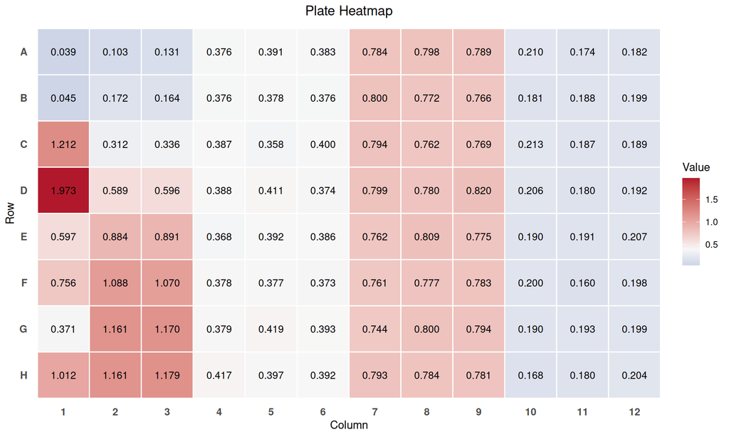

**Click to expand plate positional quality**

#### Plate Positional Quality

No significant row or column bias detected (all within 2 SD of plate mean).

Response by Row

| Row | Mean Response | SD | Flag |
| --- | --- | --- | --- |
| A | 0.36 | 0.28 | OK |
| B | 0.37 | 0.27 | OK |
| C | 0.49 | 0.32 | OK |
| D | 0.61 | 0.49 | OK |
| E | 0.54 | 0.28 | OK |
| F | 0.58 | 0.34 | OK |
| G | 0.57 | 0.36 | OK |
| H | 0.62 | 0.38 | OK |

## Dose-Response Curve with Unknown Samples

**Dose-Response Curve with Unknown Samples**

[interactive chart not shown]

## Parallelism and Relative Potency

*Not applicable: Fewer than 2 independent standard curves available for parallelism testing.*

## Interpretation & Recommendations

**Quality warnings detected:** High sample CV (max 80.9% > 15% limit). Review flagged items before use.

> **Two independent range indicators appear in this report:**
> - **Interpolated / Extrapolated** refers to whether the estimated concentration falls within the range of fitted standard concentrations on this plate. This is a statement about curve coverage.
> - **Within range / ULOQ** refers to whether the estimate falls within the validated linear (quantifiable) range of the dose-response curve, defined by EC20/EC80 for RBA or %B/B0 bounds (default 20–80%) for ELISA. This is a statement about reporting quality.

> A sample can be interpolated but outside the quantifiable range (e.g., the response falls on the flat portion of the curve near the top or bottom asymptote), or within the quantifiable range but technically extrapolated (if the user provided few standards). Both flags should be considered when interpreting results.

**Quantification status breakdown (per well):**

- Interpolated: 72

*QC profile: ELISA (R² >= 0.98, CV <= 15%, Hill slope [-3.0, -0.2], Recovery [80%, 120%])*

### Exclusion Audit

**Exclusion Audit Trail**

*No exclusions were applied during this analysis.*

**Abbreviations**

**RBA**

Radioligand Binding Assay

**ELISA**

Enzyme-Linked Immunosorbent Assay

**LL.4**

Four-parameter log-logistic dose-response function

**IC50**

Half-maximal inhibitory concentration

**EC20**

Concentration producing 20% of maximal response

**EC80**

Concentration producing 80% of maximal response

**%B/B0**

Percent bound relative to maximum specific binding (B0)

**B0**

Maximum specific binding (zero-standard well)

**NSB**

Non-specific binding

**LLOQ**

Lower Limit of Quantification

**ULOQ**

Upper Limit of Quantification

**Cal. high**

Upper limit of the calibration curve (concentration of the highest standard)

**Cal. low**

Lower limit of the calibration curve (concentration of the lowest standard)

**CV**

Coefficient of variation between replicate wells, %. Replicates with CV > 30% are flagged with a red left-border on the row.

**SD**

Standard Deviation

**SE**

Standard Error of the Mean

**CI**

Confidence Interval

**Report Generated:** 2026-05-15 **Contact:** kr.moeller@iaea.org **Feedback:** [Online Form](https://forms.office.com/e/q8eqJfp4QM)

*Automated bioassay analysis using modular system v2.0*

# Overall Conclusions

## Cross-Wavelength Concordance

Comparison of sample concentrations estimated at different wavelengths.

### Bland-Altman Analysis

Each plot compares calculated sample concentrations between two wavelengths: the dashed line shows the mean bias (systematic difference), while the red dotted lines mark the limits of agreement (mean +/- 1.96 SD). If all points fall within the limits of agreement and the bias is close to zero, the two wavelengths can be considered interchangeable for quantification purposes.

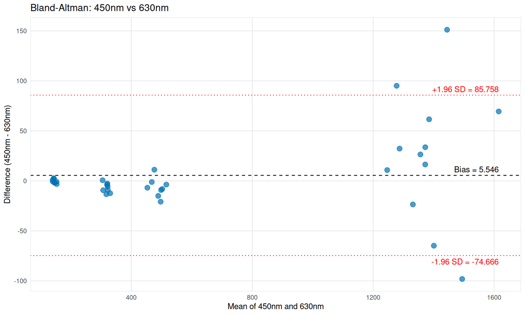

## Multi-Wavelength Bias Visualization

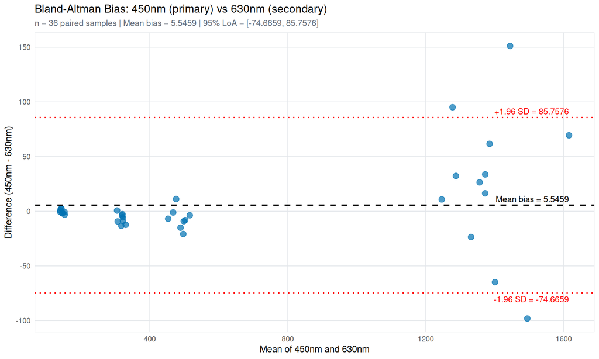

## Wavelength Performance Summary

**Recommendations:**

- Choose the wavelength with highest R² (best curve fit)
- Verify sample CVs are acceptable (<20% preferred)
- Consider which wavelength gives the most reliable separation between samples

**Report Generated:** 2026-05-15 **Contact:** kr.moeller@iaea.org **Feedback:** [Online Form](https://forms.office.com/e/q8eqJfp4QM)

*Automated multi-wavelength bioassay analysis using modular system v2.0*